# Risk Factor Analysis

## Outcome Variable

**Outcome Variable:** swasted

## Predictor Variables

**Intervention Variable:** meducyrs

**Adjustment Set:**

- arm
- W_mage
- feducyrs
- hhwealth_quart
- W_mhtcm
- W_mwtkg
- W_mbmi
- W_gagebrth
- W_birthwt
- W_birthlen
- single
- W_nrooms
- impsan
- delta_W_mage
- delta_feducyrs
- delta_hhwealth_quart
- delta_W_mhtcm
- delta_W_mwtkg
- delta_W_mbmi
- delta_W_gagebrth
- delta_W_birthwt
- delta_W_birthlen
- delta_single
- delta_W_nrooms
- delta_impsan

## Stratifying Variables

The analysis was stratified on these variable(s):

- agecat
- studyid
- country

## Data Summary

| agecat | studyid | country | meducyrs | swasted | n_cell | n |
| --- | --- | --- | --- | --- | --- | --- |
| Birth | ki0047075b-MAL-ED | BANGLADESH | High | 0 | 63 | 175 |
| Birth | ki0047075b-MAL-ED | BANGLADESH | High | 1 | 1 | 175 |
| Birth | ki0047075b-MAL-ED | BANGLADESH | Low | 0 | 58 | 175 |
| Birth | ki0047075b-MAL-ED | BANGLADESH | Low | 1 | 2 | 175 |
| Birth | ki0047075b-MAL-ED | BANGLADESH | Medium | 0 | 48 | 175 |
| Birth | ki0047075b-MAL-ED | BANGLADESH | Medium | 1 | 3 | 175 |
| Birth | ki0047075b-MAL-ED | BRAZIL | High | 0 | 18 | 62 |
| Birth | ki0047075b-MAL-ED | BRAZIL | High | 1 | 0 | 62 |
| Birth | ki0047075b-MAL-ED | BRAZIL | Low | 0 | 17 | 62 |
| Birth | ki0047075b-MAL-ED | BRAZIL | Low | 1 | 0 | 62 |
| Birth | ki0047075b-MAL-ED | BRAZIL | Medium | 0 | 27 | 62 |
| Birth | ki0047075b-MAL-ED | BRAZIL | Medium | 1 | 0 | 62 |
| Birth | ki0047075b-MAL-ED | INDIA | High | 0 | 8 | 38 |
| Birth | ki0047075b-MAL-ED | INDIA | High | 1 | 0 | 38 |
| Birth | ki0047075b-MAL-ED | INDIA | Low | 0 | 18 | 38 |
| Birth | ki0047075b-MAL-ED | INDIA | Low | 1 | 0 | 38 |
| Birth | ki0047075b-MAL-ED | INDIA | Medium | 0 | 12 | 38 |
| Birth | ki0047075b-MAL-ED | INDIA | Medium | 1 | 0 | 38 |
| Birth | ki0047075b-MAL-ED | NEPAL | High | 0 | 4 | 24 |
| Birth | ki0047075b-MAL-ED | NEPAL | High | 1 | 1 | 24 |
| Birth | ki0047075b-MAL-ED | NEPAL | Low | 0 | 12 | 24 |
| Birth | ki0047075b-MAL-ED | NEPAL | Low | 1 | 0 | 24 |
| Birth | ki0047075b-MAL-ED | NEPAL | Medium | 0 | 7 | 24 |
| Birth | ki0047075b-MAL-ED | NEPAL | Medium | 1 | 0 | 24 |
| Birth | ki0047075b-MAL-ED | PERU | High | 0 | 65 | 228 |
| Birth | ki0047075b-MAL-ED | PERU | High | 1 | 0 | 228 |
| Birth | ki0047075b-MAL-ED | PERU | Low | 0 | 83 | 228 |
| Birth | ki0047075b-MAL-ED | PERU | Low | 1 | 0 | 228 |
| Birth | ki0047075b-MAL-ED | PERU | Medium | 0 | 80 | 228 |
| Birth | ki0047075b-MAL-ED | PERU | Medium | 1 | 0 | 228 |

[output cut: 396 more lines]

The following strata were considered:

- agecat: 24 months, studyid: ki0047075b-MAL-ED, country: BANGLADESH
- agecat: 24 months, studyid: ki0047075b-MAL-ED, country: BRAZIL
- agecat: 24 months, studyid: ki0047075b-MAL-ED, country: INDIA
- agecat: 24 months, studyid: ki0047075b-MAL-ED, country: NEPAL
- agecat: 24 months, studyid: ki0047075b-MAL-ED, country: PERU
- agecat: 24 months, studyid: ki0047075b-MAL-ED, country: SOUTH AFRICA
- agecat: 24 months, studyid: ki0047075b-MAL-ED, country: TANZANIA, UNITED REPUBLIC OF
- agecat: 24 months, studyid: ki1000108-CMC-V-BCS-2002, country: INDIA
- agecat: 24 months, studyid: ki1000108-IRC, country: INDIA
- agecat: 24 months, studyid: ki1000109-EE, country: PAKISTAN
- agecat: 24 months, studyid: ki1017093-NIH-Birth, country: BANGLADESH
- agecat: 24 months, studyid: ki1017093b-PROVIDE, country: BANGLADESH
- agecat: 24 months, studyid: ki1017093c-NIH-Crypto, country: BANGLADESH
- agecat: 24 months, studyid: ki1066203-TanzaniaChild2, country: TANZANIA, UNITED REPUBLIC OF
- agecat: 24 months, studyid: ki1113344-GMS-Nepal, country: NEPAL
- agecat: 24 months, studyid: ki1119695-PROBIT, country: BELARUS
- agecat: 24 months, studyid: ki1126311-ZVITAMBO, country: ZIMBABWE
- agecat: 24 months, studyid: ki1135781-COHORTS, country: GUATEMALA
- agecat: 24 months, studyid: ki1135781-COHORTS, country: INDIA
- agecat: 24 months, studyid: ki1135781-COHORTS, country: PHILIPPINES
- agecat: 24 months, studyid: ki1148112-LCNI-5, country: MALAWI
- agecat: 24 months, studyid: kiGH5241-JiVitA-3, country: BANGLADESH
- agecat: 24 months, studyid: kiGH5241-JiVitA-4, country: BANGLADESH
- agecat: 6 months, studyid: ki0047075b-MAL-ED, country: BANGLADESH
- agecat: 6 months, studyid: ki0047075b-MAL-ED, country: BRAZIL
- agecat: 6 months, studyid: ki0047075b-MAL-ED, country: INDIA
- agecat: 6 months, studyid: ki0047075b-MAL-ED, country: NEPAL
- agecat: 6 months, studyid: ki0047075b-MAL-ED, country: PERU
- agecat: 6 months, studyid: ki0047075b-MAL-ED, country: SOUTH AFRICA
- agecat: 6 months, studyid: ki0047075b-MAL-ED, country: TANZANIA, UNITED REPUBLIC OF
- agecat: 6 months, studyid: ki1000108-CMC-V-BCS-2002, country: INDIA
- agecat: 6 months, studyid: ki1000108-IRC, country: INDIA
- agecat: 6 months, studyid: ki1000109-EE, country: PAKISTAN
- agecat: 6 months, studyid: ki1000304b-SAS-CompFeed, country: INDIA
- agecat: 6 months, studyid: ki1000304b-SAS-FoodSuppl, country: INDIA
- agecat: 6 months, studyid: ki1017093-NIH-Birth, country: BANGLADESH
- agecat: 6 months, studyid: ki1017093b-PROVIDE, country: BANGLADESH
- agecat: 6 months, studyid: ki1017093c-NIH-Crypto, country: BANGLADESH
- agecat: 6 months, studyid: ki1066203-TanzaniaChild2, country: TANZANIA, UNITED REPUBLIC OF
- agecat: 6 months, studyid: ki1112895-Guatemala BSC, country: GUATEMALA
- agecat: 6 months, studyid: ki1113344-GMS-Nepal, country: NEPAL
- agecat: 6 months, studyid: ki1119695-PROBIT, country: BELARUS
- agecat: 6 months, studyid: ki1126311-ZVITAMBO, country: ZIMBABWE
- agecat: 6 months, studyid: ki1135781-COHORTS, country: GUATEMALA
- agecat: 6 months, studyid: ki1135781-COHORTS, country: INDIA
- agecat: 6 months, studyid: ki1135781-COHORTS, country: PHILIPPINES
- agecat: 6 months, studyid: ki1148112-LCNI-5, country: MALAWI
- agecat: 6 months, studyid: kiGH5241-JiVitA-3, country: BANGLADESH
- agecat: 6 months, studyid: kiGH5241-JiVitA-4, country: BANGLADESH
- agecat: Birth, studyid: ki0047075b-MAL-ED, country: BANGLADESH
- agecat: Birth, studyid: ki0047075b-MAL-ED, country: BRAZIL
- agecat: Birth, studyid: ki0047075b-MAL-ED, country: INDIA
- agecat: Birth, studyid: ki0047075b-MAL-ED, country: NEPAL
- agecat: Birth, studyid: ki0047075b-MAL-ED, country: PERU
- agecat: Birth, studyid: ki0047075b-MAL-ED, country: SOUTH AFRICA
- agecat: Birth, studyid: ki0047075b-MAL-ED, country: TANZANIA, UNITED REPUBLIC OF
- agecat: Birth, studyid: ki1000108-CMC-V-BCS-2002, country: INDIA
- agecat: Birth, studyid: ki1000108-IRC, country: INDIA
- agecat: Birth, studyid: ki1000109-EE, country: PAKISTAN
- agecat: Birth, studyid: ki1000304b-SAS-CompFeed, country: INDIA
- agecat: Birth, studyid: ki1017093-NIH-Birth, country: BANGLADESH
- agecat: Birth, studyid: ki1017093b-PROVIDE, country: BANGLADESH
- agecat: Birth, studyid: ki1017093c-NIH-Crypto, country: BANGLADESH
- agecat: Birth, studyid: ki1113344-GMS-Nepal, country: NEPAL
- agecat: Birth, studyid: ki1119695-PROBIT, country: BELARUS
- agecat: Birth, studyid: ki1126311-ZVITAMBO, country: ZIMBABWE
- agecat: Birth, studyid: ki1135781-COHORTS, country: GUATEMALA
- agecat: Birth, studyid: ki1135781-COHORTS, country: INDIA
- agecat: Birth, studyid: ki1135781-COHORTS, country: PHILIPPINES
- agecat: Birth, studyid: kiGH5241-JiVitA-3, country: BANGLADESH
- agecat: Birth, studyid: kiGH5241-JiVitA-4, country: BANGLADESH

### Dropped Strata

Some strata were dropped due to rare outcomes:

- agecat: Birth, studyid: ki0047075b-MAL-ED, country: BANGLADESH
- agecat: Birth, studyid: ki0047075b-MAL-ED, country: BRAZIL
- agecat: Birth, studyid: ki0047075b-MAL-ED, country: INDIA
- agecat: Birth, studyid: ki0047075b-MAL-ED, country: NEPAL
- agecat: Birth, studyid: ki0047075b-MAL-ED, country: PERU
- agecat: Birth, studyid: ki0047075b-MAL-ED, country: SOUTH AFRICA
- agecat: Birth, studyid: ki0047075b-MAL-ED, country: TANZANIA, UNITED REPUBLIC OF
- agecat: Birth, studyid: ki1000108-CMC-V-BCS-2002, country: INDIA
- agecat: Birth, studyid: ki1000109-EE, country: PAKISTAN
- agecat: Birth, studyid: ki1000304b-SAS-CompFeed, country: INDIA
- agecat: Birth, studyid: ki1017093b-PROVIDE, country: BANGLADESH
- agecat: 6 months, studyid: ki0047075b-MAL-ED, country: BANGLADESH
- agecat: 6 months, studyid: ki0047075b-MAL-ED, country: BRAZIL
- agecat: 6 months, studyid: ki0047075b-MAL-ED, country: INDIA
- agecat: 6 months, studyid: ki0047075b-MAL-ED, country: NEPAL
- agecat: 6 months, studyid: ki0047075b-MAL-ED, country: PERU
- agecat: 6 months, studyid: ki0047075b-MAL-ED, country: SOUTH AFRICA
- agecat: 6 months, studyid: ki0047075b-MAL-ED, country: TANZANIA, UNITED REPUBLIC OF
- agecat: 6 months, studyid: ki1000108-CMC-V-BCS-2002, country: INDIA
- agecat: 6 months, studyid: ki1000109-EE, country: PAKISTAN
- agecat: 6 months, studyid: ki1000304b-SAS-CompFeed, country: INDIA
- agecat: 6 months, studyid: ki1000304b-SAS-FoodSuppl, country: INDIA
- agecat: 6 months, studyid: ki1017093-NIH-Birth, country: BANGLADESH
- agecat: 6 months, studyid: ki1017093b-PROVIDE, country: BANGLADESH
- agecat: 6 months, studyid: ki1017093c-NIH-Crypto, country: BANGLADESH
- agecat: 6 months, studyid: ki1066203-TanzaniaChild2, country: TANZANIA, UNITED REPUBLIC OF
- agecat: 6 months, studyid: ki1112895-Guatemala BSC, country: GUATEMALA
- agecat: 6 months, studyid: ki1113344-GMS-Nepal, country: NEPAL
- agecat: 6 months, studyid: ki1119695-PROBIT, country: BELARUS
- agecat: 6 months, studyid: ki1135781-COHORTS, country: GUATEMALA
- agecat: 6 months, studyid: ki1148112-LCNI-5, country: MALAWI
- agecat: 6 months, studyid: kiGH5241-JiVitA-4, country: BANGLADESH
- agecat: 24 months, studyid: ki0047075b-MAL-ED, country: BANGLADESH
- agecat: 24 months, studyid: ki0047075b-MAL-ED, country: BRAZIL
- agecat: 24 months, studyid: ki0047075b-MAL-ED, country: INDIA
- agecat: 24 months, studyid: ki0047075b-MAL-ED, country: NEPAL
- agecat: 24 months, studyid: ki0047075b-MAL-ED, country: PERU
- agecat: 24 months, studyid: ki0047075b-MAL-ED, country: SOUTH AFRICA
- agecat: 24 months, studyid: ki0047075b-MAL-ED, country: TANZANIA, UNITED REPUBLIC OF
- agecat: 24 months, studyid: ki1000108-CMC-V-BCS-2002, country: INDIA
- agecat: 24 months, studyid: ki1000108-IRC, country: INDIA
- agecat: 24 months, studyid: ki1000109-EE, country: PAKISTAN
- agecat: 24 months, studyid: ki1017093-NIH-Birth, country: BANGLADESH
- agecat: 24 months, studyid: ki1017093b-PROVIDE, country: BANGLADESH
- agecat: 24 months, studyid: ki1017093c-NIH-Crypto, country: BANGLADESH
- agecat: 24 months, studyid: ki1066203-TanzaniaChild2, country: TANZANIA, UNITED REPUBLIC OF
- agecat: 24 months, studyid: ki1113344-GMS-Nepal, country: NEPAL
- agecat: 24 months, studyid: ki1119695-PROBIT, country: BELARUS
- agecat: 24 months, studyid: ki1135781-COHORTS, country: GUATEMALA
- agecat: 24 months, studyid: ki1135781-COHORTS, country: INDIA
- agecat: 24 months, studyid: ki1148112-LCNI-5, country: MALAWI

## Methods Detail

We’re interested in the causal parameters $E[Y_a]$ for all values of $a \in \mathcal{A}$. These parameters represent the mean outcome if, possibly contrary to fact, we intervened to set all units to have $A=a$. Under the randomization and positivity assumptions, these are identified by the statistical parameters $\psi_a=E_W[E_{Y|A,W}(Y|A=a,W)]$. In addition, we’re interested in the mean of $Y$, $E[Y]$ under no intervention (the observed mean). We will estimate these parameters by using SuperLearner to fit the relevant likelihood factors – $E_{Y|A,W}(Y|A=a,W)$ and $p(A=a|W)$, and then updating our likelihood fit using a joint TMLE.

For unadjusted analyses ($W=\{\}$), initial likelihoods were estimated using Lrnr_glm to estimate the simple $E(Y|A)$ and Lrnr_mean to estimate $p(A)$. For adjusted analyses, a small library containing Lrnr_glmnet, Lrnr_xgboost, and Lrnr_mean was used.

Having estimated these parameters, we will then use the delta method to estimate relative risks and attributable risks relative to a prespecified baseline level of $A$.

# Results Detail

## Results Plots

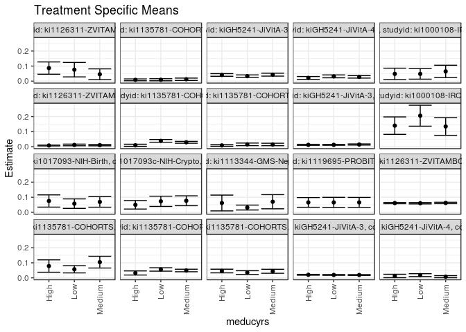

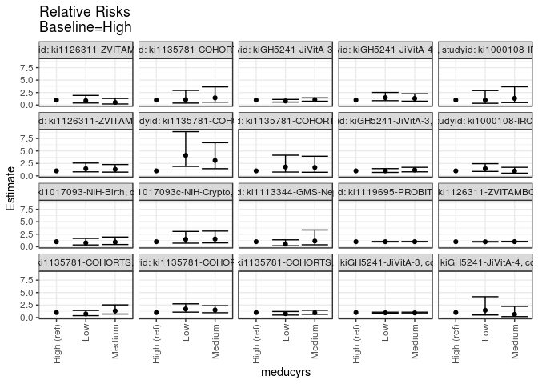

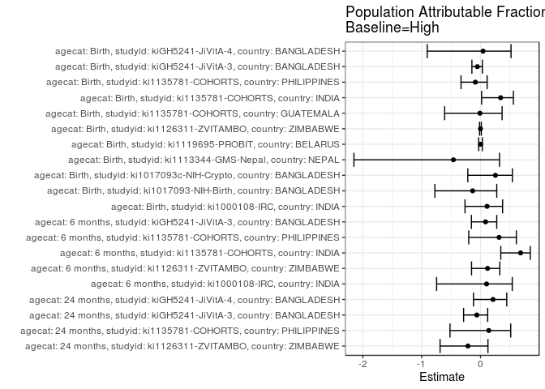

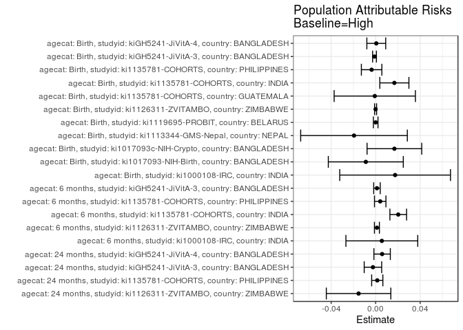

## Results Table

### Parameter: TSM

| agecat | studyid | country | intervention_level | baseline_level | estimate | ci_lower | ci_upper |
| --- | --- | --- | --- | --- | --- | --- | --- |
| Birth | ki1000108-IRC | INDIA | High | NA | 0.1399688 | 0.0820490 | 0.1978886 |
| Birth | ki1000108-IRC | INDIA | Low | NA | 0.2060597 | 0.1363269 | 0.2757924 |
| Birth | ki1000108-IRC | INDIA | Medium | NA | 0.1345425 | 0.0757205 | 0.1933644 |
| Birth | ki1017093-NIH-Birth | BANGLADESH | High | NA | 0.0749548 | 0.0344473 | 0.1154622 |
| Birth | ki1017093-NIH-Birth | BANGLADESH | Low | NA | 0.0574021 | 0.0259976 | 0.0888065 |
| Birth | ki1017093-NIH-Birth | BANGLADESH | Medium | NA | 0.0689289 | 0.0338818 | 0.1039760 |
| Birth | ki1017093c-NIH-Crypto | BANGLADESH | High | NA | 0.0496553 | 0.0215837 | 0.0777269 |
| Birth | ki1017093c-NIH-Crypto | BANGLADESH | Low | NA | 0.0729131 | 0.0387985 | 0.1070277 |
| Birth | ki1017093c-NIH-Crypto | BANGLADESH | Medium | NA | 0.0766063 | 0.0437036 | 0.1095091 |
| Birth | ki1113344-GMS-Nepal | NEPAL | High | NA | 0.0617284 | 0.0092776 | 0.1141792 |
| Birth | ki1113344-GMS-Nepal | NEPAL | Low | NA | 0.0315315 | 0.0152644 | 0.0477987 |
| Birth | ki1113344-GMS-Nepal | NEPAL | Medium | NA | 0.0701754 | 0.0232478 | 0.1171031 |
| Birth | ki1119695-PROBIT | BELARUS | High | NA | 0.0655014 | 0.0332968 | 0.0977060 |
| Birth | ki1119695-PROBIT | BELARUS | Low | NA | 0.0655164 | 0.0318042 | 0.0992286 |
| Birth | ki1119695-PROBIT | BELARUS | Medium | NA | 0.0656496 | 0.0325667 | 0.0987325 |
| Birth | ki1126311-ZVITAMBO | ZIMBABWE | High | NA | 0.0614152 | 0.0571642 | 0.0656662 |
| Birth | ki1126311-ZVITAMBO | ZIMBABWE | Low | NA | 0.0602708 | 0.0557197 | 0.0648218 |
| Birth | ki1126311-ZVITAMBO | ZIMBABWE | Medium | NA | 0.0621666 | 0.0574413 | 0.0668920 |
| Birth | ki1135781-COHORTS | GUATEMALA | High | NA | 0.0783505 | 0.0372718 | 0.1194292 |
| Birth | ki1135781-COHORTS | GUATEMALA | Low | NA | 0.0568315 | 0.0327723 | 0.0808907 |
| Birth | ki1135781-COHORTS | GUATEMALA | Medium | NA | 0.1043405 | 0.0652473 | 0.1434337 |
| Birth | ki1135781-COHORTS | INDIA | High | NA | 0.0323833 | 0.0187937 | 0.0459728 |
| Birth | ki1135781-COHORTS | INDIA | Low | NA | 0.0557763 | 0.0445177 | 0.0670349 |
| Birth | ki1135781-COHORTS | INDIA | Medium | NA | 0.0489046 | 0.0405426 | 0.0572665 |
| Birth | ki1135781-COHORTS | PHILIPPINES | High | NA | 0.0453878 | 0.0332701 | 0.0575055 |
| Birth | ki1135781-COHORTS | PHILIPPINES | Low | NA | 0.0349204 | 0.0224379 | 0.0474030 |
| Birth | ki1135781-COHORTS | PHILIPPINES | Medium | NA | 0.0436981 | 0.0302937 | 0.0571025 |
| Birth | kiGH5241-JiVitA-3 | BANGLADESH | High | NA | 0.0204494 | 0.0175442 | 0.0233546 |
| Birth | kiGH5241-JiVitA-3 | BANGLADESH | Low | NA | 0.0193773 | 0.0167928 | 0.0219619 |
| Birth | kiGH5241-JiVitA-3 | BANGLADESH | Medium | NA | 0.0189859 | 0.0161086 | 0.0218633 |
| Birth | kiGH5241-JiVitA-4 | BANGLADESH | High | NA | 0.0124224 | 0.0011008 | 0.0237440 |
| Birth | kiGH5241-JiVitA-4 | BANGLADESH | Low | NA | 0.0180941 | 0.0086591 | 0.0275291 |
| Birth | kiGH5241-JiVitA-4 | BANGLADESH | Medium | NA | 0.0079260 | 0.0011127 | 0.0147393 |
| 6 months | ki1000108-IRC | INDIA | High | NA | 0.0483871 | 0.0105720 | 0.0862022 |
| 6 months | ki1000108-IRC | INDIA | Low | NA | 0.0482759 | 0.0133443 | 0.0832074 |
| 6 months | ki1000108-IRC | INDIA | Medium | NA | 0.0647482 | 0.0237890 | 0.1057074 |
| 6 months | ki1126311-ZVITAMBO | ZIMBABWE | High | NA | 0.0081901 | 0.0053654 | 0.0110149 |
| 6 months | ki1126311-ZVITAMBO | ZIMBABWE | Low | NA | 0.0118331 | 0.0063489 | 0.0173172 |
| 6 months | ki1126311-ZVITAMBO | ZIMBABWE | Medium | NA | 0.0107206 | 0.0060830 | 0.0153582 |
| 6 months | ki1135781-COHORTS | INDIA | High | NA | 0.0094980 | 0.0024947 | 0.0165012 |
| 6 months | ki1135781-COHORTS | INDIA | Low | NA | 0.0388952 | 0.0298972 | 0.0478931 |
| 6 months | ki1135781-COHORTS | INDIA | Medium | NA | 0.0293508 | 0.0232029 | 0.0354988 |
| 6 months | ki1135781-COHORTS | PHILIPPINES | High | NA | 0.0088670 | 0.0030987 | 0.0146353 |
| 6 months | ki1135781-COHORTS | PHILIPPINES | Low | NA | 0.0157767 | 0.0072669 | 0.0242865 |
| 6 months | ki1135781-COHORTS | PHILIPPINES | Medium | NA | 0.0149942 | 0.0069033 | 0.0230852 |
| 6 months | kiGH5241-JiVitA-3 | BANGLADESH | High | NA | 0.0124932 | 0.0090367 | 0.0159497 |
| 6 months | kiGH5241-JiVitA-3 | BANGLADESH | Low | NA | 0.0125354 | 0.0095251 | 0.0155458 |
| 6 months | kiGH5241-JiVitA-3 | BANGLADESH | Medium | NA | 0.0146973 | 0.0109395 | 0.0184552 |
| 24 months | ki1126311-ZVITAMBO | ZIMBABWE | High | NA | 0.0869565 | 0.0461962 | 0.1277169 |
| 24 months | ki1126311-ZVITAMBO | ZIMBABWE | Low | NA | 0.0762712 | 0.0283242 | 0.1242182 |
| 24 months | ki1126311-ZVITAMBO | ZIMBABWE | Medium | NA | 0.0458015 | 0.0099610 | 0.0816420 |
| 24 months | ki1135781-COHORTS | PHILIPPINES | High | NA | 0.0087816 | 0.0027219 | 0.0148412 |
| 24 months | ki1135781-COHORTS | PHILIPPINES | Low | NA | 0.0093583 | 0.0024568 | 0.0162598 |
| 24 months | ki1135781-COHORTS | PHILIPPINES | Medium | NA | 0.0126582 | 0.0048609 | 0.0204555 |
| 24 months | kiGH5241-JiVitA-3 | BANGLADESH | High | NA | 0.0412188 | 0.0325163 | 0.0499213 |
| 24 months | kiGH5241-JiVitA-3 | BANGLADESH | Low | NA | 0.0335150 | 0.0254100 | 0.0416199 |
| 24 months | kiGH5241-JiVitA-3 | BANGLADESH | Medium | NA | 0.0432967 | 0.0335289 | 0.0530644 |
| 24 months | kiGH5241-JiVitA-4 | BANGLADESH | High | NA | 0.0215219 | 0.0120789 | 0.0309648 |
| 24 months | kiGH5241-JiVitA-4 | BANGLADESH | Low | NA | 0.0318955 | 0.0224098 | 0.0413811 |
| 24 months | kiGH5241-JiVitA-4 | BANGLADESH | Medium | NA | 0.0285552 | 0.0203133 | 0.0367970 |

### Parameter: E(Y)

| agecat | studyid | country | intervention_level | baseline_level | estimate | ci_lower | ci_upper |
| --- | --- | --- | --- | --- | --- | --- | --- |
| Birth | ki1000108-IRC | INDIA | NA | NA | 0.1574344 | 0.1188345 | 0.1960344 |
| Birth | ki1017093-NIH-Birth | BANGLADESH | NA | NA | 0.0660870 | 0.0457632 | 0.0864107 |
| Birth | ki1017093c-NIH-Crypto | BANGLADESH | NA | NA | 0.0664781 | 0.0481022 | 0.0848539 |
| Birth | ki1113344-GMS-Nepal | NEPAL | NA | NA | 0.0422535 | 0.0266438 | 0.0578632 |
| Birth | ki1119695-PROBIT | BELARUS | NA | NA | 0.0655098 | 0.0324802 | 0.0985393 |
| Birth | ki1126311-ZVITAMBO | ZIMBABWE | NA | NA | 0.0613321 | 0.0571909 | 0.0654732 |
| Birth | ki1135781-COHORTS | GUATEMALA | NA | NA | 0.0775401 | 0.0583612 | 0.0967191 |
| Birth | ki1135781-COHORTS | INDIA | NA | NA | 0.0491904 | 0.0431214 | 0.0552594 |
| Birth | ki1135781-COHORTS | PHILIPPINES | NA | NA | 0.0417385 | 0.0344572 | 0.0490198 |
| Birth | kiGH5241-JiVitA-3 | BANGLADESH | NA | NA | 0.0194018 | 0.0169900 | 0.0218136 |
| Birth | kiGH5241-JiVitA-4 | BANGLADESH | NA | NA | 0.0129653 | 0.0075421 | 0.0183885 |
| 6 months | ki1000108-IRC | INDIA | NA | NA | 0.0539216 | 0.0319786 | 0.0758646 |
| 6 months | ki1126311-ZVITAMBO | ZIMBABWE | NA | NA | 0.0093029 | 0.0072609 | 0.0113448 |
| 6 months | ki1135781-COHORTS | INDIA | NA | NA | 0.0297762 | 0.0252454 | 0.0343071 |
| 6 months | ki1135781-COHORTS | PHILIPPINES | NA | NA | 0.0129342 | 0.0086762 | 0.0171922 |
| 6 months | kiGH5241-JiVitA-3 | BANGLADESH | NA | NA | 0.0136578 | 0.0115849 | 0.0157307 |
| 24 months | ki1126311-ZVITAMBO | ZIMBABWE | NA | NA | 0.0715935 | 0.0472820 | 0.0959051 |
| 24 months | ki1135781-COHORTS | PHILIPPINES | NA | NA | 0.0102082 | 0.0062264 | 0.0141901 |
| 24 months | kiGH5241-JiVitA-3 | BANGLADESH | NA | NA | 0.0387570 | 0.0344303 | 0.0430837 |
| 24 months | kiGH5241-JiVitA-4 | BANGLADESH | NA | NA | 0.0273074 | 0.0220923 | 0.0325225 |

### Parameter: RR

| agecat | studyid | country | intervention_level | baseline_level | estimate | ci_lower | ci_upper |
| --- | --- | --- | --- | --- | --- | --- | --- |
| Birth | ki1000108-IRC | INDIA | High | High | 1.0000000 | 1.0000000 | 1.000000 |
| Birth | ki1000108-IRC | INDIA | Low | High | 1.4721827 | 0.8859182 | 2.446413 |
| Birth | ki1000108-IRC | INDIA | Medium | High | 0.9612319 | 0.5407236 | 1.708760 |
| Birth | ki1017093-NIH-Birth | BANGLADESH | High | High | 1.0000000 | 1.0000000 | 1.000000 |
| Birth | ki1017093-NIH-Birth | BANGLADESH | Low | High | 0.7658225 | 0.3547032 | 1.653450 |
| Birth | ki1017093-NIH-Birth | BANGLADESH | Medium | High | 0.9196064 | 0.4376027 | 1.932520 |
| Birth | ki1017093c-NIH-Crypto | BANGLADESH | High | High | 1.0000000 | 1.0000000 | 1.000000 |
| Birth | ki1017093c-NIH-Crypto | BANGLADESH | Low | High | 1.4683846 | 0.7050158 | 3.058305 |
| Birth | ki1017093c-NIH-Crypto | BANGLADESH | Medium | High | 1.5427623 | 0.7588645 | 3.136417 |
| Birth | ki1113344-GMS-Nepal | NEPAL | High | High | 1.0000000 | 1.0000000 | 1.000000 |
| Birth | ki1113344-GMS-Nepal | NEPAL | Low | High | 0.5108108 | 0.1890368 | 1.380301 |
| Birth | ki1113344-GMS-Nepal | NEPAL | Medium | High | 1.1368421 | 0.3855700 | 3.351947 |
| Birth | ki1119695-PROBIT | BELARUS | High | High | 1.0000000 | 1.0000000 | 1.000000 |
| Birth | ki1119695-PROBIT | BELARUS | Low | High | 1.0002288 | 0.9539574 | 1.048744 |
| Birth | ki1119695-PROBIT | BELARUS | Medium | High | 1.0022631 | 0.9605664 | 1.045770 |
| Birth | ki1126311-ZVITAMBO | ZIMBABWE | High | High | 1.0000000 | 1.0000000 | 1.000000 |
| Birth | ki1126311-ZVITAMBO | ZIMBABWE | Low | High | 0.9813654 | 0.9406251 | 1.023870 |
| Birth | ki1126311-ZVITAMBO | ZIMBABWE | Medium | High | 1.0122351 | 0.9670933 | 1.059484 |
| Birth | ki1135781-COHORTS | GUATEMALA | High | High | 1.0000000 | 1.0000000 | 1.000000 |
| Birth | ki1135781-COHORTS | GUATEMALA | Low | High | 0.7253496 | 0.3718032 | 1.415082 |
| Birth | ki1135781-COHORTS | GUATEMALA | Medium | High | 1.3317144 | 0.7008174 | 2.530564 |
| Birth | ki1135781-COHORTS | INDIA | High | High | 1.0000000 | 1.0000000 | 1.000000 |
| Birth | ki1135781-COHORTS | INDIA | Low | High | 1.7223800 | 1.0813135 | 2.743508 |
| Birth | ki1135781-COHORTS | INDIA | Medium | High | 1.5101799 | 0.9603371 | 2.374836 |
| Birth | ki1135781-COHORTS | PHILIPPINES | High | High | 1.0000000 | 1.0000000 | 1.000000 |
| Birth | ki1135781-COHORTS | PHILIPPINES | Low | High | 0.7693792 | 0.4927706 | 1.201257 |
| Birth | ki1135781-COHORTS | PHILIPPINES | Medium | High | 0.9627713 | 0.6417471 | 1.444383 |
| Birth | kiGH5241-JiVitA-3 | BANGLADESH | High | High | 1.0000000 | 1.0000000 | 1.000000 |
| Birth | kiGH5241-JiVitA-3 | BANGLADESH | Low | High | 0.9475735 | 0.8422377 | 1.066083 |
| Birth | kiGH5241-JiVitA-3 | BANGLADESH | Medium | High | 0.9284353 | 0.8079280 | 1.066917 |
| Birth | kiGH5241-JiVitA-4 | BANGLADESH | High | High | 1.0000000 | 1.0000000 | 1.000000 |
| Birth | kiGH5241-JiVitA-4 | BANGLADESH | Low | High | 1.4565742 | 0.5084765 | 4.172481 |
| Birth | kiGH5241-JiVitA-4 | BANGLADESH | Medium | High | 0.6380449 | 0.1818054 | 2.239215 |
| 6 months | ki1000108-IRC | INDIA | High | High | 1.0000000 | 1.0000000 | 1.000000 |
| 6 months | ki1000108-IRC | INDIA | Low | High | 0.9977011 | 0.3439183 | 2.894314 |
| 6 months | ki1000108-IRC | INDIA | Medium | High | 1.3381295 | 0.4895938 | 3.657299 |
| 6 months | ki1126311-ZVITAMBO | ZIMBABWE | High | High | 1.0000000 | 1.0000000 | 1.000000 |
| 6 months | ki1126311-ZVITAMBO | ZIMBABWE | Low | High | 1.4447957 | 0.8108050 | 2.574521 |
| 6 months | ki1126311-ZVITAMBO | ZIMBABWE | Medium | High | 1.3089601 | 0.7526956 | 2.276321 |
| 6 months | ki1135781-COHORTS | INDIA | High | High | 1.0000000 | 1.0000000 | 1.000000 |
| 6 months | ki1135781-COHORTS | INDIA | Low | High | 4.0951039 | 1.8908265 | 8.869072 |
| 6 months | ki1135781-COHORTS | INDIA | Medium | High | 3.0902230 | 1.4358105 | 6.650932 |
| 6 months | ki1135781-COHORTS | PHILIPPINES | High | High | 1.0000000 | 1.0000000 | 1.000000 |
| 6 months | ki1135781-COHORTS | PHILIPPINES | Low | High | 1.7792611 | 0.7642414 | 4.142369 |
| 6 months | ki1135781-COHORTS | PHILIPPINES | Medium | High | 1.6910163 | 0.7262384 | 3.937462 |
| 6 months | kiGH5241-JiVitA-3 | BANGLADESH | High | High | 1.0000000 | 1.0000000 | 1.000000 |
| 6 months | kiGH5241-JiVitA-3 | BANGLADESH | Low | High | 1.0033811 | 0.6941474 | 1.450374 |
| 6 months | kiGH5241-JiVitA-3 | BANGLADESH | Medium | High | 1.1764245 | 0.8100409 | 1.708524 |
| 24 months | ki1126311-ZVITAMBO | ZIMBABWE | High | High | 1.0000000 | 1.0000000 | 1.000000 |
| 24 months | ki1126311-ZVITAMBO | ZIMBABWE | Low | High | 0.8771186 | 0.4004071 | 1.921388 |
| 24 months | ki1126311-ZVITAMBO | ZIMBABWE | Medium | High | 0.5267176 | 0.2115570 | 1.311379 |
| 24 months | ki1135781-COHORTS | PHILIPPINES | High | High | 1.0000000 | 1.0000000 | 1.000000 |
| 24 months | ki1135781-COHORTS | PHILIPPINES | Low | High | 1.0656751 | 0.3881533 | 2.925812 |
| 24 months | ki1135781-COHORTS | PHILIPPINES | Medium | High | 1.4414557 | 0.5715907 | 3.635109 |
| 24 months | kiGH5241-JiVitA-3 | BANGLADESH | High | High | 1.0000000 | 1.0000000 | 1.000000 |
| 24 months | kiGH5241-JiVitA-3 | BANGLADESH | Low | High | 0.8130992 | 0.5914353 | 1.117840 |
| 24 months | kiGH5241-JiVitA-3 | BANGLADESH | Medium | High | 1.0504104 | 0.7681027 | 1.436477 |
| 24 months | kiGH5241-JiVitA-4 | BANGLADESH | High | High | 1.0000000 | 1.0000000 | 1.000000 |
| 24 months | kiGH5241-JiVitA-4 | BANGLADESH | Low | High | 1.4820027 | 0.8702284 | 2.523857 |
| 24 months | kiGH5241-JiVitA-4 | BANGLADESH | Medium | High | 1.3267988 | 0.7783030 | 2.261838 |

### Parameter: PAR

| agecat | studyid | country | intervention_level | baseline_level | estimate | ci_lower | ci_upper |
| --- | --- | --- | --- | --- | --- | --- | --- |
| Birth | ki1000108-IRC | INDIA | High | NA | 0.0174656 | -0.0323006 | 0.0672318 |
| Birth | ki1017093-NIH-Birth | BANGLADESH | High | NA | -0.0088678 | -0.0425660 | 0.0248303 |
| Birth | ki1017093c-NIH-Crypto | BANGLADESH | High | NA | 0.0168228 | -0.0077393 | 0.0413848 |
| Birth | ki1113344-GMS-Nepal | NEPAL | High | NA | -0.0194749 | -0.0674050 | 0.0284552 |
| Birth | ki1119695-PROBIT | BELARUS | High | NA | 0.0000084 | -0.0020636 | 0.0020803 |
| Birth | ki1126311-ZVITAMBO | ZIMBABWE | High | NA | -0.0000831 | -0.0009865 | 0.0008203 |
| Birth | ki1135781-COHORTS | GUATEMALA | High | NA | -0.0008104 | -0.0373286 | 0.0357078 |
| Birth | ki1135781-COHORTS | INDIA | High | NA | 0.0168071 | 0.0037377 | 0.0298766 |
| Birth | ki1135781-COHORTS | PHILIPPINES | High | NA | -0.0036493 | -0.0128639 | 0.0055653 |
| Birth | kiGH5241-JiVitA-3 | BANGLADESH | High | NA | -0.0010476 | -0.0027649 | 0.0006698 |
| Birth | kiGH5241-JiVitA-4 | BANGLADESH | High | NA | 0.0005429 | -0.0079350 | 0.0090208 |
| 6 months | ki1000108-IRC | INDIA | High | NA | 0.0055345 | -0.0267498 | 0.0378187 |
| 6 months | ki1126311-ZVITAMBO | ZIMBABWE | High | NA | 0.0011127 | -0.0011123 | 0.0033378 |
| 6 months | ki1135781-COHORTS | INDIA | High | NA | 0.0202783 | 0.0127813 | 0.0277752 |
| 6 months | ki1135781-COHORTS | PHILIPPINES | High | NA | 0.0040672 | -0.0010750 | 0.0092095 |
| 6 months | kiGH5241-JiVitA-3 | BANGLADESH | High | NA | 0.0011646 | -0.0017583 | 0.0040875 |
| 24 months | ki1126311-ZVITAMBO | ZIMBABWE | High | NA | -0.0153630 | -0.0443536 | 0.0136276 |
| 24 months | ki1135781-COHORTS | PHILIPPINES | High | NA | 0.0014267 | -0.0035989 | 0.0064523 |
| 24 months | kiGH5241-JiVitA-3 | BANGLADESH | High | NA | -0.0024618 | -0.0103151 | 0.0053915 |
| 24 months | kiGH5241-JiVitA-4 | BANGLADESH | High | NA | 0.0057855 | -0.0015937 | 0.0131647 |

### Parameter: PAF

| agecat | studyid | country | intervention_level | baseline_level | estimate | ci_lower | ci_upper |
| --- | --- | --- | --- | --- | --- | --- | --- |
| Birth | ki1000108-IRC | INDIA | High | NA | 0.1109389 | -0.2641353 | 0.3747270 |
| Birth | ki1017093-NIH-Birth | BANGLADESH | High | NA | -0.1341841 | -0.7762680 | 0.2757999 |
| Birth | ki1017093c-NIH-Crypto | BANGLADESH | High | NA | 0.2530574 | -0.2163219 | 0.5413029 |
| Birth | ki1113344-GMS-Nepal | NEPAL | High | NA | -0.4609053 | -2.1514607 | 0.3227761 |
| Birth | ki1119695-PROBIT | BELARUS | High | NA | 0.0001280 | -0.0319772 | 0.0312343 |
| Birth | ki1126311-ZVITAMBO | ZIMBABWE | High | NA | -0.0013554 | -0.0161925 | 0.0132651 |
| Birth | ki1135781-COHORTS | GUATEMALA | High | NA | -0.0104514 | -0.6104567 | 0.3660108 |
| Birth | ki1135781-COHORTS | INDIA | High | NA | 0.3416750 | 0.0185096 | 0.5584350 |
| Birth | ki1135781-COHORTS | PHILIPPINES | High | NA | -0.0874321 | -0.3316122 | 0.1119722 |
| Birth | kiGH5241-JiVitA-3 | BANGLADESH | High | NA | -0.0539940 | -0.1468942 | 0.0313812 |
| Birth | kiGH5241-JiVitA-4 | BANGLADESH | High | NA | 0.0418754 | -0.9064856 | 0.5184843 |
| 6 months | ki1000108-IRC | INDIA | High | NA | 0.1026393 | -0.7462155 | 0.5388563 |
| 6 months | ki1126311-ZVITAMBO | ZIMBABWE | High | NA | 0.1196110 | -0.1527664 | 0.3276307 |
| 6 months | ki1135781-COHORTS | INDIA | High | NA | 0.6810218 | 0.3441589 | 0.8448601 |
| 6 months | ki1135781-COHORTS | PHILIPPINES | High | NA | 0.3144546 | -0.2005200 | 0.6085259 |
| 6 months | kiGH5241-JiVitA-3 | BANGLADESH | High | NA | 0.0852680 | -0.1551382 | 0.2756411 |
| 24 months | ki1126311-ZVITAMBO | ZIMBABWE | High | NA | -0.2145863 | -0.6877207 | 0.1259100 |
| 24 months | ki1135781-COHORTS | PHILIPPINES | High | NA | 0.1397585 | -0.5193606 | 0.5129429 |
| 24 months | kiGH5241-JiVitA-3 | BANGLADESH | High | NA | -0.0635192 | -0.2874752 | 0.1214797 |
| 24 months | kiGH5241-JiVitA-4 | BANGLADESH | High | NA | 0.2118662 | -0.1202260 | 0.4455092 |